# Comparing Groups: Statistical Tests

Session 1

Luis F. Gómez L.

luis.gomezl@unimilitar.edu.co

Distance Learning Faculty

16 September, 2026

# Please Read Me

- This presentation is based on (Chapman & Feit, 2019, Chapter 6)
- **Purpose**
  - Understand the use of statistical tests to identify differences between groups in data

# Consumer segmentation survey

```r
segmentation <- read_csv(
  file = "http://goo.gl/qw303p"
)

segmentation |>
  head(n = 5)
```

```
# A tibble: 5 × 7
    age gender income  kids ownHome subscribe Segment
  <dbl> <chr>   <dbl> <dbl> <chr>   <chr>     <chr>
1  47.3 Male   49483.     2 ownNo   subNo     Suburb mix
2  31.4 Male   35546.     1 ownYes  subNo     Suburb mix
3  43.2 Male   44169.     0 ownYes  subNo     Suburb mix
4  37.3 Female 81042.     1 ownNo   subNo     Suburb mix
5  41.0 Female 79353.     3 ownYes  subNo     Suburb mix
```

- **Import data**

```r
segmentation |>
  count(Segment)
```

```
# A tibble: 4 × 2
  Segment        n
  <chr>      <int>
1 Moving up     70
2 Suburb mix   100
3 Travelers     80
4 Urban hip     50
```

```r
segmentation |>
  count(subscribe, ownHome) |>
  pivot_wider(
    id_cols = subscribe,
    names_from = ownHome,
    values_from = n
  )
```

```
# A tibble: 2 × 3
  subscribe ownNo ownYes
  <chr>     <int>  <int>
1 subNo       137    123
2 subYes       22     18
```

- Chi-squared test
- Chi-squared test for given probabilities

$H_0: p_1 = \frac{1}{4} \land p_2 = \frac{1}{4} \land p_3 = \frac{1}{4} \land p_4 = \frac{1}{4}$

$H_1: p_1 \neq \frac{1}{4} \lor p_2 \neq \frac{1}{4} \lor p_3 = \frac{1}{4} \lor p_4 \neq \frac{1}{4}$

$$\begin{align}
\chi^2 & = \sum_{i=1}^n \frac{(Observed_i - Expected_i)^2}{Expected_i} \\
& = \frac{(70 - 300\frac{1}{4})^2}{300\frac{1}{4}} + \frac{(100 - 300\frac{1}{4})^2}{300\frac{1}{4}} +
\frac{(80 - 300\frac{1}{4})^2}{300\frac{1}{4}} +
\frac{(50 - 300\frac{1}{4})^2}{300\frac{1}{4}}
\end{align}$$

- Chi-squared test for given probabilities

```r
chi_statistic <- table(segmentation$Segment) |>
  chisq.test(
    p = c(1 / 4, 1 / 4, 1 / 4, 1 / 4)
  )

chi_statistic
```

```
    Chi-squared test for given probabilities

data:  table(segmentation$Segment)
X-squared = 17.333, df = 3, p-value = 0.0006035
```

```r
library(tidymodels)
segmentation |>
  chisq_test(
    response = Segment,
    p = c(1 / 4, 1 / 4, 1 / 4, 1 / 4)
  )
```

```
# A tibble: 1 × 3
  statistic chisq_df  p_value
      <dbl>    <dbl>    <dbl>
1      17.3        3 0.000603
```

- **Base R way**
- **tidymodels way**

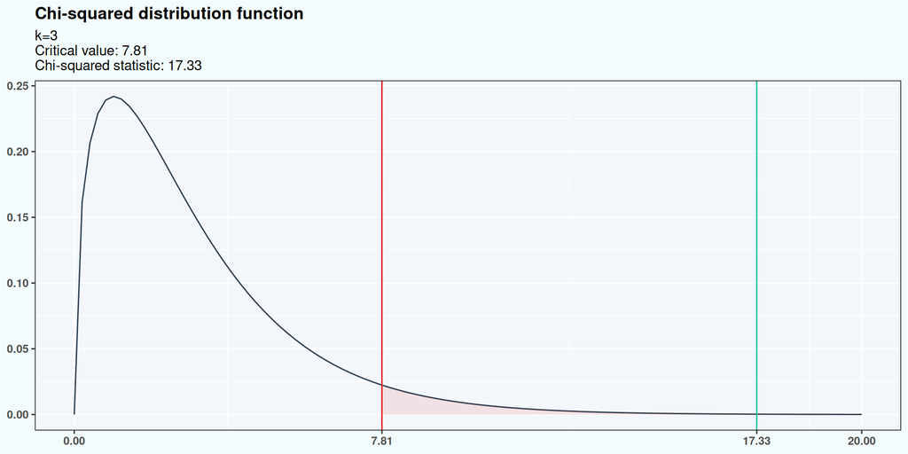

Figure 1: Chi-squared test for given probabilities

- Pearson’s Chi-squared test

$H_0: p_{11} = \frac{260}{300}\frac{159}{300} \land p_{12} = \frac{260}{300}\frac{141}{300} \land p_{21} = \frac{40}{300}\frac{159}{300} \land p_{22} = \frac{40}{300}\frac{141}{300}$

$H_1: p_{11} \neq \frac{260}{300}\frac{159}{300} \lor p_{12} \neq \frac{260}{300}\frac{141}{300} \lor p_{21} \neq \frac{40}{300}\frac{159}{300} \lor p_{22} \neq \frac{40}{300}\frac{141}{300}$

$$\begin{align}
\chi^2 & = \sum_{i=1}^n \frac{(Observed_i - Expected_i)^2}{Expected_i} \\
& = \frac{(137 - 300\frac{260}{300}\frac{159}{300})^2}{300\frac{260}{300}\frac{159}{300}} + \frac{(123 - 300\frac{260}{300}\frac{141}{300})^2}{300\frac{260}{300}\frac{141}{300}} \\
& \: \: \: \: \: + \frac{(22 - 300\frac{40}{300}\frac{159}{300})^2}{300\frac{40}{300}\frac{159}{300}} + \frac{(18 - 300\frac{40}{300}\frac{141}{300})^2}{300\frac{40}{300}\frac{141}{300}}
\end{align}$$

- Pearson’s Chi-squared test

```r
chi_statistic <- chisq.test(
  table(
    segmentation$subscribe,
    segmentation$ownHome
  ),
  correct = FALSE
)

chi_statistic
```

```
    Pearson's Chi-squared test

data:  table(segmentation$subscribe, segmentation$ownHome)
X-squared = 0.074113, df = 1, p-value = 0.7854
```

```r
segmentation |>
  chisq_test(
    formula = subscribe ~ ownHome,
    correct = FALSE
  )
```

```
# A tibble: 1 × 3
  statistic chisq_df p_value
      <dbl>    <int>   <dbl>
1    0.0741        1   0.785
```

- **Base R way**
- **tidymodels way**

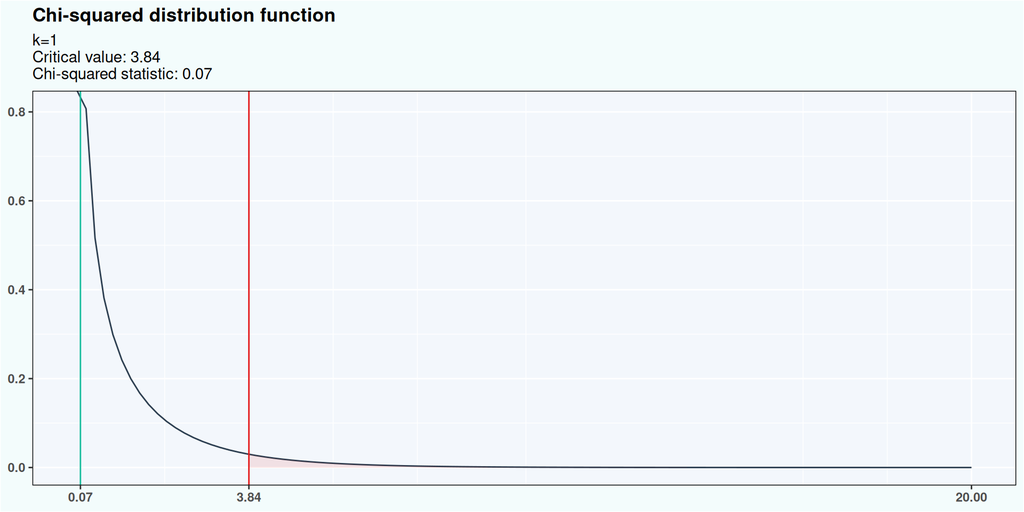

Figure 2: Pearson’s Chi-squared test

- 2 sample t-test: independent samples

```r
segmentation |>
  ggplot() +
  geom_histogram(
    aes(x = income),
    color = 'black'
  ) +
  facet_wrap(facets = vars(ownHome))
```

```r
segmentation |>
  group_by(ownHome) |>
  summarise(
    mean_income = mean(income),
    var_income = var(income),
    n = n()
  )
```

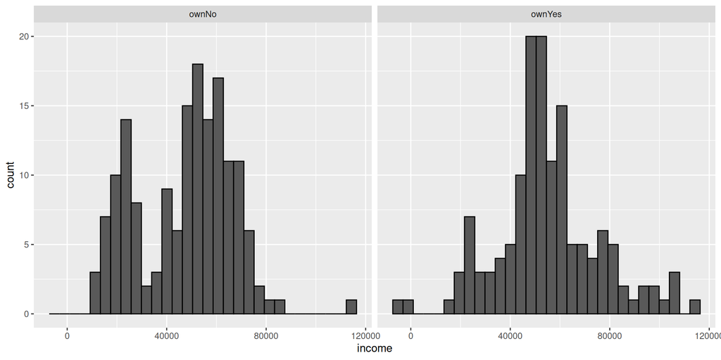

Figure 3: Visualizing distributions to compare means in 2 samples

```
# A tibble: 2 × 4
  ownHome mean_income var_income     n
  <chr>         <dbl>      <dbl> <int>
1 ownNo        47391. 358692875.   159
2 ownYes       54935. 430890091.   141
```

- 2 sample t-test: independent samples

$H_0: \mu_{ownNo} - \mu_{ownYes}= 0$

$H_1: \mu_{ownNo} - \mu_{ownYes} \neq 0$

- 2 sample t-test: independent samples

```r
t.test(
  formula = income ~ ownHome,
  data = segmentation,
  alternative = 'two.sided',
  mu = 0,
  conf.level = 0.95
)
```

```
    Welch Two Sample t-test

data:  income by ownHome
t = -3.2731, df = 285.25, p-value = 0.001195
alternative hypothesis: true difference in means between group ownNo and group ownYes is not equal to 0
95 percent confidence interval:
 -12080.155  -3007.193
sample estimates:
 mean in group ownNo mean in group ownYes
            47391.01             54934.68
```

```r
segmentation |>
  t_test(
    formula = income ~ ownHome,
    alternative = "two-sided",
    order = c("ownNo", "ownYes"),
    mu = 0,
    conf_level = 0.95
  )
```

```
# A tibble: 1 × 7
  statistic  t_df p_value alternative estimate lower_ci upper_ci
      <dbl> <dbl>   <dbl> <chr>          <dbl>    <dbl>    <dbl>
1     -3.27  285. 0.00119 two.sided     -7544.  -12080.   -3007.
```

- **R base way**
- **tidymodels way**

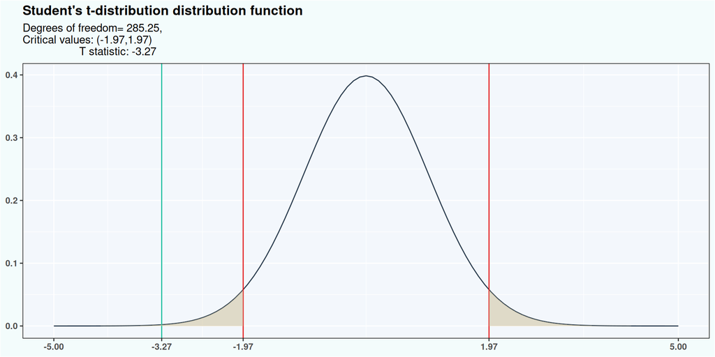

Figure 4: 2 sample t-test: independent samples

- 2 sample t-test: independent samples
  - Confidence interval

    $$c_L < \mu_{ownNo} - \mu_{ownYes} < c_U$$
    - $\mu_{ownNo} - \mu_{ownYes}$ is not a random variable, so we need to use a random variable

    $$P \left( t_L < \frac{(\overline{x}_{ownNo} - \overline{x}_{ownYes}) - (\mu_{ownNo} - \mu_{ownYes})}{\sqrt{\frac{s^2_{ownNo}}{n_{ownNo} } +\frac{s^2_{ownYes}}{n_{ownYes}}}} < t_U \right) = 0.95$$
    - $\overline{x}_{ownNo} - \overline{x}_{ownYes}$ is a random variable
- 2 sample t-test: independent samples
  - Confidence interval
    - $\frac{(\overline{x}_{ownNo} - \overline{x}_{ownYes}) - (\mu_{ownNo} - \mu_{ownYes})}{\sqrt{\frac{s^2_{ownNo}}{n_{ownNo} } +\frac{s^2_{ownYes}}{n_{ownYes}}}}$ is also a random variable with student’s t-distribution and $\nu \approx \frac{\left(\frac{s_{ownNo}^2}{n_{ownNo}} + \frac{s_2^2}{n_{ownYes}}\right)^2}{\frac{\left(\frac{s_{ownNo}^2}{n_{ownNo}}\right)^2}{n_{ownNo}-1} + \frac{\left(\frac{s_2^2}{n_{ownYes}}\right)^2}{n_{ownYes}-1}} = 285.2521$ degrees of freedom
    - Also we need to specify $t_L$ and $t_U$

      ```r
      t_L <- qt(p = 0.025, df = 285.25, lower.tail = TRUE)
      t_L
      ```

      ```
      [1] -1.968315
      ```

      ```r
      t_U <- qt(p = 0.975, df = 285.25, lower.tail = TRUE)
      t_U
      ```

      ```
      [1] 1.968315
      ```

- 2 sample t-test: independent samples
  - Confidence interval

    $$\begin{alignedat}{2}
    & P \left( (\overline{x}_{ownNo} - \overline{x}_{ownYes}) - t_U \times \sqrt{\frac{s^2_{ownNo}}{n_{ownNo} } + \frac{s^2_{ownYes}}{n_{ownYes}}} \right. \\
    & \left. \quad \quad < \mu_{ownNo} - \mu_{ownYes} < (\overline{x}_{ownNo} - \overline{x}_{ownYes}) - t_L \times \sqrt{\frac{s^2_{ownNo}}{n_{ownNo} } + \frac{s^2_{ownYes}}{n_{ownYes}}} \right) &&= 0.95 \\[1.5ex]
    & P \left( -7543.674 - 1.968315 \times 2304.753 \right. \\
    & \left. \quad \quad < \mu_{ownNo} - \mu_{ownYes} < -7543.674 + 1.968315 \times 2304.753 \right) &&= 0.95 \\[1.5ex]
    & P \left( -12080.16 < \mu_{ownNo} - \mu_{ownYes} < -3007.193 \right) &&= 0.95
    \end{alignedat}$$
    - In the long run 95% of confidence intervals constructed in this manner will contain the true parameter
- Testing Multiple Group Means
  - Analysis of Variance (ANOVA)

```r
segmentation |>
  summarise(
    mean = mean(income),
    variance = var(income),
    n = n()
  )
```

```
# A tibble: 1 × 3
    mean   variance     n
   <dbl>      <dbl> <int>
1 50937. 405520897.   300
```

```r
segmentation |>
  group_by(Segment) |>
  summarise(
    mean = mean(income),
    variance = var(income),
    n = n()
  )
```

```
# A tibble: 4 × 4
  Segment      mean   variance     n
  <chr>       <dbl>      <dbl> <int>
1 Moving up  53091.  92862689.    70
2 Suburb mix 55034. 142761527.   100
3 Travelers  62214. 564173979.    80
4 Urban hip  21682.  23885953.    50
```

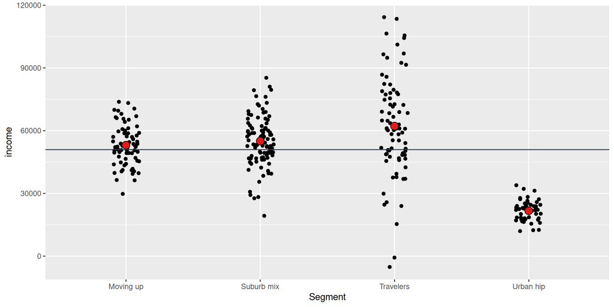

Figure 5: Visualizing Analysis of Variance (ANOVA)

- Testing Multiple Group Means: Analysis of Variance (ANOVA)

$H_0: \mu_{Moving\;up} = \mu_{Suburb\;mix} = \mu_{Travelers} = \mu_{Urban\;hip}$

$H_1: \text{At least one group mean is different from the rest}$

$n = \sum_{j=1}^4 n_j = n_1 + \cdots + n_4 = 70 + 100 + 80 + 50 = 300$

$\overline{income} = \frac{1}{n} \sum_{j=1}^4 \sum_{i=1}^{n_j} income_{ij} = 50936.54$

$\overline{income}_j = \frac{1}{n_j} \sum_{i=1}^{n_j} income_{ij}$

$$F = \frac{\frac{\sum_{j=1}^4 \sum_{i=1}^{n_j} (\overline{income}_j - \overline{income})^2}{4-1}}{\frac{\sum_{j=1}^4 \sum_{i=1}^{n_j} (income_{ij} - \overline{income}_j)^2}{300 - 4}} = \frac{\frac{54969675428}{3}}{\frac{66281072794}{296}} = \frac{18323225143}{223922543} = 81.82841$$

```r
anova_table <- aov(
  data = segmentation,
  formula = income ~ Segment
) |>
  anova() |>
  tidy()

anova_table
```

```
# A tibble: 2 × 6
  term         df        sumsq       meansq statistic   p.value
  <chr>     <int>        <dbl>        <dbl>     <dbl>     <dbl>
1 Segment       3 54969675428. 18323225143.      81.8  1.41e-38
2 Residuals   296 66281072794.   223922543.      NA   NA
```

- Testing Multiple Group Means
  - Analysis of Variance (ANOVA)
    - **tidymodels way**

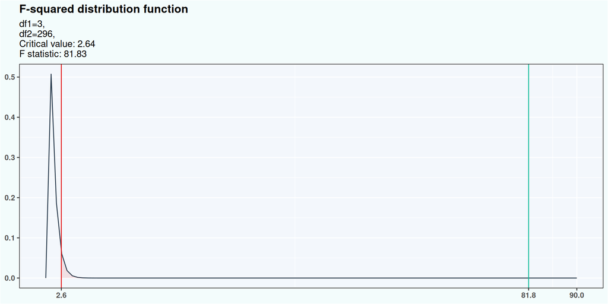

Figure 6: Testing Multiple Group Means: Analysis of Variance (ANOVA)

- Testing Multiple Group Means
  - Analysis of Variance (ANOVA)

```r
segmentation |>
  distinct(Segment) |>
  arrange(Segment) |>
  rowid_to_column(var = 'i')
```

```
# A tibble: 4 × 2
      i Segment
  <int> <chr>
1     1 Moving up
2     2 Suburb mix
3     3 Travelers
4     4 Urban hip
```

```r
segmentation |>
  distinct(ownHome) |>
  rowid_to_column(var = 'j')
```

```
# A tibble: 2 × 2
      j ownHome
  <int> <chr>
1     1 ownNo
2     2 ownYes
```

- By `Segment`
- By `ownHome`
- Testing Multiple Group Means
  - Analysis of Variance (ANOVA)

```r
segmentation |>
  count(
    Segment,
    ownHome,
    name = "n_ij"
  )
```

```
# A tibble: 8 × 3
  Segment    ownHome  n_ij
  <chr>      <chr>   <int>
1 Moving up  ownNo      47
2 Moving up  ownYes     23
3 Suburb mix ownNo      52
4 Suburb mix ownYes     48
5 Travelers  ownNo      20
6 Travelers  ownYes     60
7 Urban hip  ownNo      40
8 Urban hip  ownYes     10
```

- Number of elements in each group
  - $n_{11} = 47, n_{12} = 23$
  - $n_{21} = 52, n_{22} = 48$
  - $n_{31} = 20, n_{32} = 60$
  - $n_{41} = 40, n_{42} = 10$
- Testing Multiple Group Means
  - Analysis of Variance (ANOVA)

```r
mu_ij <- segmentation |>
  group_by(Segment, ownHome) |>
  summarise(mean = mean(income)) |>
  ungroup()
mu_ij
```

```
# A tibble: 8 × 3
  Segment    ownHome   mean
  <chr>      <chr>    <dbl>
1 Moving up  ownNo   54498.
2 Moving up  ownYes  50216.
3 Suburb mix ownNo   54933.
4 Suburb mix ownYes  55143.
5 Travelers  ownNo   63188.
6 Travelers  ownYes  61889.
7 Urban hip  ownNo   21338.
8 Urban hip  ownYes  23059.
```

```r
segmentation |>
  select(income, Segment, ownHome) |>
  head(n = 2)
```

```
# A tibble: 2 × 3
  income Segment    ownHome
   <dbl> <chr>      <chr>
1 49483. Suburb mix ownNo
2 35546. Suburb mix ownYes
```

- Means
  - $\mu_{11} = 54497.68, \mu_{12} = 50216.37$
  - $\mu_{21} = 54932.83, \mu_{22} = 55143.21$
  - $\mu_{31} = 63188.42, \mu_{32} = 61889.12$
  - $\mu_{41} = 21337.59, \mu_{42} = 23059.27$
- Incomes
  - $income_{211} = 49482.81$
  - $income_{221} = 35546.29$
  - $\phantom{income_{ijk}}\:\:\: \vdots$

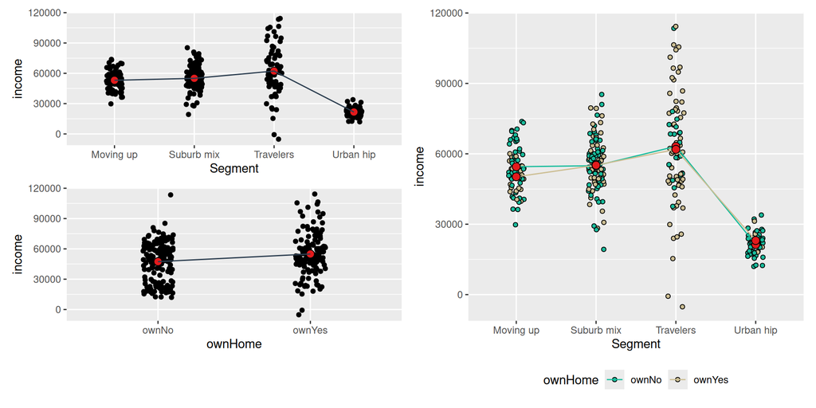

Figure 7: Visualizing Analysis of Variance (ANOVA) for 2 variables

- Testing Multiple Group Means: Analysis of Variance (ANOVA)

$$\begin{split}
income_{ijk} = & \mu + \alpha_i + \beta_j + (\alpha\beta)_{ij} + \epsilon_{ijk} \\
& \text{ where } + \epsilon_i \sim \mathcal{N}(0, \sigma^2) \\
& \text{ and } i = 1, 2, 3, 4 \\
& j = 1, 2 \\
& k = 1, \ldots n_{ij} \\
& \mu = \mu_{11} \\
& \alpha_1 = \beta_1 = 0 \\
& (\alpha\beta)_{11} = (\alpha\beta)_{12} = 0 \\
& (\alpha\beta)_{21} = (\alpha\beta)_{31} = (\alpha\beta)_{41} = 0 \\
\end{split}$$

- Testing Multiple Group Means: Analysis of Variance (ANOVA)

$$\begin{split}
\widehat{income}_{ijk} & = \widehat{\mu} + \widehat{\alpha}_i + \widehat{\beta}_j + (\widehat{\alpha\beta})_{ij} + \widehat{\epsilon}_{ijk} \\
& \text{ and } i = 1, 2, 3, 4 \\
& j = 1, 2 \\
& k = 1, \ldots n_{ij} \\
& \widehat{\mu} = \widehat{\mu}_{11} \\
& \widehat{\alpha}_2, \widehat{\alpha}_3, \widehat{\alpha}_4 \\
& \widehat{\beta}_2 \\
& (\widehat{\alpha\beta})_{22}, (\widehat{\alpha\beta})_{32}, (\widehat{\alpha\beta})_{42}
\end{split}$$

$$income_{ijk} - \widehat{income}_{ijk} = \widehat{\epsilon}_{ijk}$$

- Testing Multiple Group Means
  - Analysis of Variance (ANOVA)

```r
segmentation |>
  select(
    income,
    Segment,
    ownHome
  ) |>
  head(n = 2)
```

```r
framed <- model_frame(
  formula = income ~ Segment + ownHome + Segment:ownHome,
  data = segmentation
)

model_matrix(
  terms = framed$terms,
  data = framed$data
) |>
  head(n = 2) |>
  glimpse()
```

- Data

```
# A tibble: 2 × 3
  income Segment    ownHome
   <dbl> <chr>      <chr>
1 49483. Suburb mix ownNo
2 35546. Suburb mix ownYes
```

- Model matrix

```
Rows: 2
Columns: 8
$ `(Intercept)`                     <dbl> 1, 1
$ `SegmentSuburb mix`               <dbl> 1, 1
$ SegmentTravelers                  <dbl> 0, 0
$ `SegmentUrban hip`                <dbl> 0, 0
$ ownHomeownYes                     <dbl> 0, 1
$ `SegmentSuburb mix:ownHomeownYes` <dbl> 0, 1
$ `SegmentTravelers:ownHomeownYes`  <dbl> 0, 0
$ `SegmentUrban hip:ownHomeownYes`  <dbl> 0, 0
```

- Testing Multiple Group Means: Analysis of Variance (ANOVA)
  - Model

    $$\begin{bmatrix}
    49482.81 \\
    35546.29 \\
    \vdots
    \end{bmatrix} =
    \begin{bmatrix}
    1 & 1 & 0 & 0 & 0 & 0 & 0 & 0 \\
    1 & 1 & 0 & 0 & 1 & 1 & 0 & 0 \\
    \vdots & \vdots & \vdots & \vdots & \vdots & \vdots & \vdots & \vdots
    \end{bmatrix}
    \begin{bmatrix}
    \mu \\
    \alpha_2 \\
    \alpha_3 \\
    \alpha_4 \\
    \beta_2 \\
    (\alpha\beta)_{22} \\
    (\alpha\beta)_{32} \\
    (\alpha\beta)_{42} \\
    \end{bmatrix}$$
  - Coefficients to estimate using `aov`

    $$\widehat{\mu} = \widehat{\mu}_{11}, \widehat{\alpha}_2, \widehat{\alpha}_3, \widehat{\alpha}_4, \widehat{\beta}_2, (\widehat{\alpha\beta})_{22}, (\widehat{\alpha\beta})_{32}, (\widehat{\alpha\beta})_{42}$$
- Testing Multiple Group Means
  - Analysis of Variance (ANOVA)

```r
model_aov <- aov(
  formula = income ~ Segment + ownHome + Segment:ownHome,
  data = segmentation
)

coef(model_aov) |>
  enframe(name = "coef")
```

```
# A tibble: 8 × 2
  coef                              value
  <chr>                             <dbl>
1 (Intercept)                      54498.
2 SegmentSuburb mix                  435.
3 SegmentTravelers                  8691.
4 SegmentUrban hip                -33160.
5 ownHomeownYes                    -4281.
6 SegmentSuburb mix:ownHomeownYes   4492.
7 SegmentTravelers:ownHomeownYes    2982.
8 SegmentUrban hip:ownHomeownYes    6003.
```

- Estimated coefficients
  - $\widehat{\mu} = \widehat{\mu}_{11} = 54497.682$
  - $\widehat{\alpha}_2 = 435.152$
  - $\widehat{\alpha}_3 = 8690.738$
  - $\widehat{\alpha}_4 = -33160.091$
  - $\widehat{\beta}_2 = -4281.313$
  - $(\widehat{\alpha\beta})_{22} = 4491.690$
  - $(\widehat{\alpha\beta})_{32} = 2982.007$
  - $(\widehat{\alpha\beta})_{42} = 6002.996$
- Testing Multiple Group Means: Analysis of Variance (ANOVA)
  - Segment

    $H_0: \mu_{Moving\;up} = \mu_{Suburb\;mix} = \mu_{Travelers} = \mu_{Urban\;hip}$

    $H_1: \text{At least one group mean is different from the rest}$
  - ownHome

    $H_0: \mu_{ownNo} = \mu_{ownYes}$

    $H_1: \text{At least one group mean is different from the rest}$
  - Segment, ownHome

    $\begin{align} H_0: & \mu_{Moving\;up,\;ownNo} - \mu_{Moving\;up,\;ownYes} = \\ & \mu_{Suburb\;mix,\;ownNo} - \mu_{Suburb\;mix,\;ownYes} = \\ & \mu_{Travelers,\;ownNo} - \mu_{Travelers,\;ownYes} = \\ & \mu_{Urban\;hip,\;ownNo} - \mu_{Urban\;hip,\;ownYes} \end{align}$

    $H_1: \text{At least one difference group mean is different from the rest}$

```r
model_aov |>
  anova() |>
  tidy()
```

- Testing Multiple Group Means
  - Analysis of Variance (ANOVA)

```
# A tibble: 4 × 6
  term               df        sumsq       meansq statistic   p.value
  <chr>           <int>        <dbl>        <dbl>     <dbl>     <dbl>
1 Segment             3 54969675428. 18323225143.    81.1    3.36e-38
2 ownHome             1    69918004.    69918004.     0.310  5.78e- 1
3 Segment:ownHome     3   263285130.    87761710.     0.389  7.61e- 1
4 Residuals         292 65947869661.   225848869.    NA     NA
```

# Acknowledgments

- To my family that supports me
- To the taxpayers of Colombia and the [**UMNG students**](https://www.umng.edu.co/estudiante) who pay my salary
- To the [**Business Science**](https://www.business-science.io/) and [**R4DS Online Learning**](https://www.rfordatasci.com/) communities where I learn [**R**](https://www.r-project.org/about.html) and [**$\pi$-thon**](https://www.python.org/about/)
- To the [**R Core Team**](https://www.r-project.org/contributors.html), the creators of [**RStudio IDE**](https://posit.co/products/open-source/rstudio/), [**Quarto**](https://quarto.org/) and the authors and maintainers of the packages [**tidyverse**](https://CRAN.R-project.org/package=tidyverse), [**skimr**](https://CRAN.R-project.org/package=skimr), [**latex2exp**](https://CRAN.R-project.org/package=latex2exp), [**tidymodels**](https://CRAN.R-project.org/package=tidymodels), [**patchwork**](https://CRAN.R-project.org/package=patchwork), [**hardhat**](https://CRAN.R-project.org/package=hardhat) and [**tinytex**](https://CRAN.R-project.org/package=tinytex) for allowing me to access these tools without paying for a license

# References

Chapman, C., & Feit, E. M. (2019). *R For Marketing Research and Analytics* (2nd ed. 2019). Springer International Publishing : Imprint: Springer. https://doi-org.ezproxy.umng.edu.co/10.1007/978-3-030-14316-9